# Exploratory Weiboscope Data Analysis

Ruoqi Zhang

4/4/2019

# Weibo (微博) and Open WeiboScope Dataset

## About Weibo

Weibo (微博), widely dubbed as China’s version of Twitter, is a social networking platform provided by Sina, now a subsidiary of Alibaba Group, one of the largest Internet firms in mainland China.

Due to online censorship, Chinese Internet users are unable to access many sites that do not conform to government censorship requests or otherwise deemed sensitive. Those sites include widely used services including Twitter, Google, Facebook, Instagram, and Snapchat. Partially as a result of Chinese Internet users’ limited access to foreign services, Weibo boasts a Monthly Active User based over 400 million and is widely regarded as one of the important barometer of China’s public sentiment on social issues.

## About Open WeiboScope

The most important dataset in this project is the Open Weibo Scope dataset published by a team at Hong Kong University led by King-wa Fu. The project scraped Weibo posts and their matadata published by users with more than 1,000 followers since January 2011.

The research team published its 2012 dataset that contains over 200 million Weibo posts that fit the previous criteria. In the dataset, each week’s data is published separately. In this step of the project, we examin the WeiboScope data in Week 1, 2012.

**Because of the size of the data, the csv file is not uploaded to Github. It can be downloaded at [Weibo Scope’s Data Portal](https://hub.hku.hk/cris/dataset/dataset107483)**

## WeiboScope Data Structure

Metadata includes such as user’s anonymous id (`uid`), the platform used to publish the post (`source`), whether the post contains image(s) (`image`), original text of the post (`text`), geospatial coordinate of the post (`geo`), and time of creation of the post (`created_at`).

Additionally, as Weibo is required to conform with government’s censorship requirements in sensitive issues. This dataset also tracks whether the post is deleted. Weibo displays posts that are censored in different ways: either saying that it’s deleted (`deleted_last_seen`) or the user does not have permission to view the post (`permission_denied`).

Here’s what a regular WeiboScope entry look like:

| mid | retweeted_status_mid | uid | retweeted_uid | source | image | text | geo | created_at | deleted_last_seen | permission_denied |
| --- | --- | --- | --- | --- | --- | --- | --- | --- | --- | --- |
| mrMzWsHC0Y | m5uc2YOPT6 | u02L2H5ID | u02L2H5ID | 微博搜索 | FALSE | //@uVEQQKN14： //[兔年传奇]一颗老鼠屎掉进粥锅，粥本施舍穷人，如立即舀出老鼠屎，粥仍可让饥者裹腹。然愤青和围观者将老鼠屎使劲搅拌，毁了粥掀翻锅，饥者仍在挨饿，公知们和好事者却忙着给老鼠颁发"慈善贡献奖"。这就是2011年真实的故事--[GMM事件]，这就是当今中国病态社会的写照。 | NA | 2012-01-02 19:13:45 | 2012-03-20 04:58:21.594711 | NA |

## Post Creation Time Variation

Using a graph by ggplot, we explore the time distribution presented by the Week 1 data.

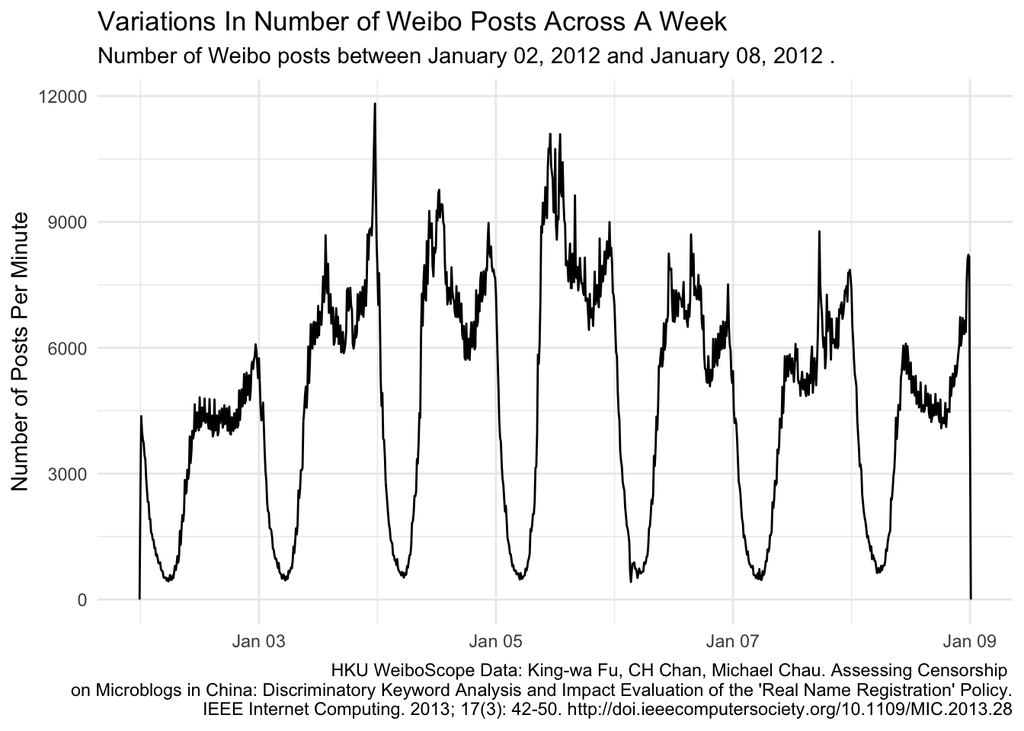

# Future Plans

In the future, for this dataset, I would like to aggregate data in all 54 weeks in 2012, and plot out the geographic distribution of Weibo posts in China.